# R Notebook

```r
library(MatrixEQTL)
library(readr)
library(dplyr)
library(ggplot2)
```

# All Against All

## Data Prep

The toy data is already prepared, consisting of: a SNP matrix, Gene Expression Matrix, and Covariates file. In the first instance, we don’t need the annotation as this exercise is an *all against all* analysis. The P value threshold is set at 0.01, however it’s unclear if this is applied to the FDR correction of the *raw* P value.

```r
useModel             <- modelLINEAR
SNP_file_name        <- "./SNP.txt"
expression_file_name <- "./GE.txt"
covariates_file_name <- "./Covariates.txt"
output_file_name     <-  tempfile()
pvOutputThreshold    <- 1e-2
errorCovariance      <- numeric()
```

## Toy Data

```r
snps                    <- SlicedData$new()
snps$fileDelimiter      <- "\t"
snps$fileOmitCharacters <- "NA"
snps$fileSkipRows       <- 1
snps$fileSkipColumns    <- 1
snps$fileSliceSize      <- 2000
snps$LoadFile(SNP_file_name)
```

```
Rows read:  15  done.
```

```r
snps
```

```
SlicedData object. For more information type: ?SlicedData
Number of columns: 16
Number of rows: 15
Data is stored in 1 slices
Top left corner of the first slice (up to 10x10):
       Sam_01 Sam_02 Sam_03 Sam_04 Sam_05 Sam_06 Sam_07 Sam_08 Sam_09 Sam_10
Snp_01      2      0      2      0      2      1      2      1      1      1
Snp_02      0      1      1      2      2      1      0      0      0      1
Snp_03      1      0      1      0      1      1      1      1      0      1
Snp_04      0      1      2      2      2      1      1      0      0      0
Snp_05      1      1      2      1      1      2      1      1      0      1
Snp_06      2      2      2      1      1      0      1      0      2      1
Snp_07      1      1      2      2      0      1      1      1      1      0
Snp_08      1      0      1      0      1      0      0      1      1      1
Snp_09      2      1      2      2      0      1      1      0      2      1
Snp_10      1      1      0      0      0      2      2      1      1      2
```

### SNPs

SNP data parameters are quite flexible, and seem to contribute to processing efficiency, such as `fileSliceSize`, which could be the amount of SNPs read into memory at once - potentially a significant bottleneck. The toy SNP dataset has 15 observations.

```r
gene                    <- SlicedData$new()
gene$fileDelimiter      <- "\t"
gene$fileOmitCharacters <- "NA"
gene$fileSkipRows       <- 1
gene$fileSkipColumns    <- 1
gene$fileSliceSize      <- 2000
gene$LoadFile(expression_file_name)
```

```
Rows read:  10  done.
```

```r
gene
```

```
SlicedData object. For more information type: ?SlicedData
Number of columns: 16
Number of rows: 10
Data is stored in 1 slices
Top left corner of the first slice (up to 10x10):
        Sam_01 Sam_02 Sam_03 Sam_04 Sam_05 Sam_06 Sam_07 Sam_08 Sam_09 Sam_10
Gene_01   4.91   4.63   5.18   5.07   5.74   5.09   5.31   5.29   4.73   5.72
Gene_02  13.78  13.14  13.18  13.04  12.85  13.07  13.09  12.83  14.94  13.86
Gene_03  12.06  12.29  13.07  13.65  13.86  12.84  12.29  13.03  13.13  14.93
Gene_04  11.63  11.88  12.74  12.66  13.16  11.99  11.97  12.81  11.74  13.29
Gene_05  14.72  14.66  14.63  15.91  15.46  14.74  15.17  15.01  14.05  14.90
Gene_06  12.29  12.23  12.47  13.21  12.63  12.18  12.44  12.45  13.22  12.70
Gene_07  12.56  12.71  12.49  13.41  13.60  12.35  12.27  13.42  14.73  15.47
Gene_08  12.27  12.58  12.61  13.02  12.86  12.32  12.30  13.19  15.21  14.60
Gene_09   9.82   9.29   8.95   8.18   8.11   9.43   9.17   9.25  10.95   9.82
Gene_10  14.24  14.52  14.62  13.65  13.46  14.04  13.97  13.73  12.29  12.01
```

### Expression

Similar to the SNP data, well parameterised, and interestingly, the `fileSliceSize` parameter isn’t engine level, and can be unbalanced. The toy expression dataset has 10 observations.

```r
cvrt                    <- SlicedData$new();
cvrt$fileDelimiter      <- "\t"
cvrt$fileOmitCharacters <- "NA"
cvrt$fileSkipRows       <- 1
cvrt$fileSkipColumns    <- 1
if(length(covariates_file_name)>0) {
  cvrt$LoadFile(covariates_file_name)
}
```

```
Rows read:  2  done.
```

```r
cvrt
```

```
SlicedData object. For more information type: ?SlicedData
Number of columns: 16
Number of rows: 2
Data is stored in 1 slices
Top left corner of the first slice (up to 10x10):
       Sam_01 Sam_02 Sam_03 Sam_04 Sam_05 Sam_06 Sam_07 Sam_08 Sam_09 Sam_10
gender      0      0      0      0      0      0      0      0      1      1
age        36     40     46     65     69     43     40     54     44     70
```

### Covariates

Covariates are extremely useful, and follow a similar convention to reading the SNP and expression data. This may require transposing relative to the data that’s currently in use.

## Running the MatrixEQTL Engine

```r
me      <- Matrix_eQTL_engine(snps              = snps,
                              gene              = gene,
                              cvrt              = cvrt,
                              output_file_name  = output_file_name,
                              pvOutputThreshold = pvOutputThreshold,
                              useModel          = useModel,
                              errorCovariance   = errorCovariance,
                              verbose           = T,
                              pvalue.hist       = T,
                              min.pv.by.genesnp = F,
                              noFDRsaveMemory   = F)
```

```
Processing covariates
Task finished in  0.002  seconds
Processing gene expression data (imputation, residualization, etc.)
Task finished in  0.003  seconds
Creating output file(s)
Task finished in  0.01  seconds
Performing eQTL analysis
100.00% done, 5 eQTLs
Task finished in  0.011  seconds
```

```r
unlink(output_file_name)
```

## Results

P value histogram can be plotted with ease, and the results come in a handy dataframe, that will need a bit of annotation adding.

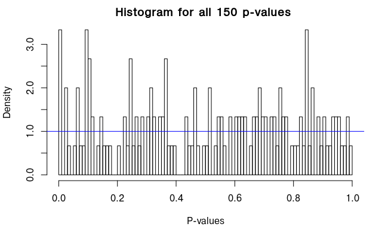

```r
plot(me)
```

```r
results <- me$all$eqtls %>%
           as.data.frame
results
```

| snps | gene | statistic | pvalue | FDR | beta |
| --- | --- | --- | --- | --- | --- |
| Snp_05 | Gene_03 | 38.812160 | 5.515519e-14 | 8.273279e-12 | 0.4101317 |
| Snp_13 | Gene_09 | -3.914403 | 2.055817e-03 | 1.541863e-01 | -0.2978847 |
| Snp_11 | Gene_06 | -3.221962 | 7.327756e-03 | 2.853368e-01 | -0.2332470 |
| Snp_04 | Gene_10 | 3.201666 | 7.608981e-03 | 2.853368e-01 | 0.2321123 |
| Snp_14 | Gene_01 | 3.070005 | 9.716705e-03 | 2.915011e-01 | 0.2147077 |

# Stratifying for Cis and Trans eQTLs

```r
snps_location_file_name <- "./snpsloc.txt"
gene_location_file_name <- "./geneloc.txt"
snpspos                 <- read_tsv(snps_location_file_name) %>% as.data.frame
genepos                 <- read_tsv(gene_location_file_name) %>% as.data.frame
output_file_name_cis    <- tempfile()
output_file_name_tra    <- tempfile()
pvOutputThreshold_cis   <- 2e-2
pvOutputThreshold_tra   <- 1e-2
cisDist                 <- 1e6
```

## Data Prep

There are a few difference between the “all against all” approach, in contrast to the cis / trans paradigm, and as such we need some additional parameters. We need the annotation for the SNPs and Expression locations, along with seperate output files for cis and trans results. Two different thresholds need to be set for the trans (0.01) and cis (0.02), in addition to the spanning region for cis-eQTLs. The SNP and Expression sets that were read in previously stay the same, as their initialisation is static, they’re reference objects.

```r
me      <- Matrix_eQTL_main(snps                  = snps,
                            gene                  = gene,
                            cvrt                  = cvrt,
                            output_file_name      = output_file_name_tra,
                            pvOutputThreshold     = pvOutputThreshold_tra,
                            useModel              = useModel,
                            errorCovariance       = errorCovariance,
                            verbose               = T,
                            output_file_name.cis  = output_file_name_cis,
                            pvOutputThreshold.cis = pvOutputThreshold_cis,
                            snpspos               = snpspos,
                            genepos               = genepos,
                            cisDist               = cisDist,
                            pvalue.hist           = "qqplot",
                            min.pv.by.genesnp     = F,
                            noFDRsaveMemory       = F)
```

```
Matching data files and location files
10 of 10  genes matched
15 of 15  SNPs matched
Task finished in  0.008  seconds
Processing covariates
Task finished in  0.004  seconds
Processing gene expression data (imputation, residualization, etc.)
Task finished in  0.004  seconds
Creating output file(s)
Task finished in  0.044  seconds
Performing eQTL analysis
100.00% done, 2 cis-eQTLs, 3 trans-eQTLs
Task finished in  0.026  seconds
```

```r
unlink(output_file_name_tra)
unlink(output_file_name_cis)
```

## Cis / Trans Run

Similar to the all against all run, but double the time to 200ths of a second - still an impressive time.

```r
results_cis   <- me$cis$eqtls  %>% as.data.frame
results_trans <- me$trans$eqtls %>% as.data.frame
results_cis; results_trans
```

| snps | gene | statistic | pvalue | FDR | beta |
| --- | --- | --- | --- | --- | --- |
| Snp_05 | Gene_03 | 38.812160 | 5.515519e-14 | 5.515519e-12 | 0.4101317 |
| Snp_04 | Gene_10 | 3.201666 | 7.608981e-03 | 3.804491e-01 | 0.2321123 |

| snps | gene | statistic | pvalue | FDR | beta |
| --- | --- | --- | --- | --- | --- |
| Snp_13 | Gene_09 | -3.914403 | 0.002055817 | 0.1027908 | -0.2978847 |
| Snp_11 | Gene_06 | -3.221962 | 0.007327756 | 0.1619451 | -0.2332470 |
| Snp_14 | Gene_01 | 3.070005 | 0.009716705 | 0.1619451 | 0.2147077 |

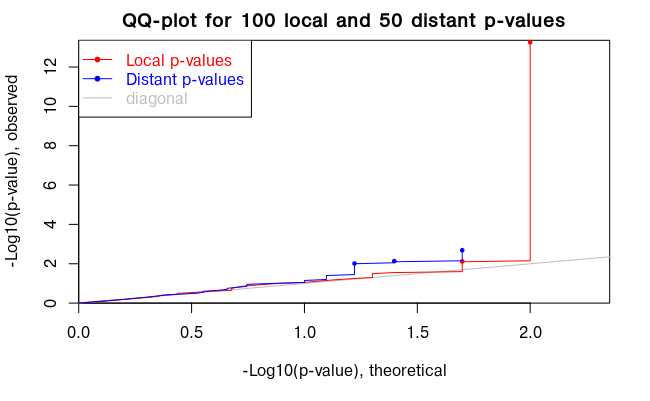

```r
plot(me)
```